# Ferris’s Project

# #1: Creating a light curve of a Milky Way Cepheid variable

## AA Gemini

> Parallax = 0.1878 milliarcseconds  
> Distance (in parsecs) = 5324.814

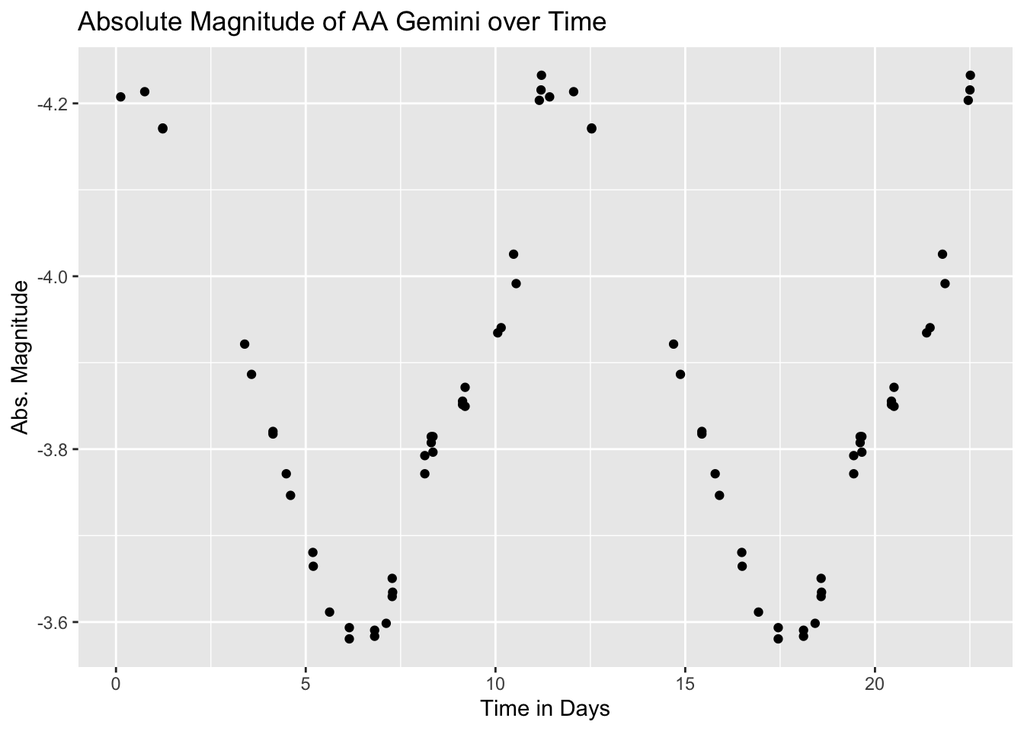

> The smallest Absolute Magnitude (Highest Luminosity) is -4.2325221.  
> The period between light curves is 11.302 days.

## AO Auriga

> Parallax = 0.1268 milliarcseconds  
> Distance (in parsecs) = 7886.435

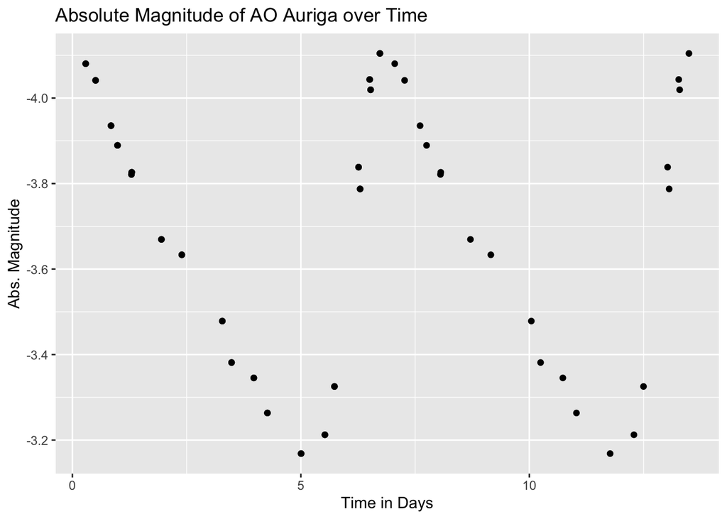

> The smallest Absolute Magnitude (Highest Luminosity) is -4.1044037.  
> The period between light curves is 6.763 days.

## BF Ophiuchus

> Parallax = 1.1764 milliarcseconds  
> Distance (in parsecs) = 850.051

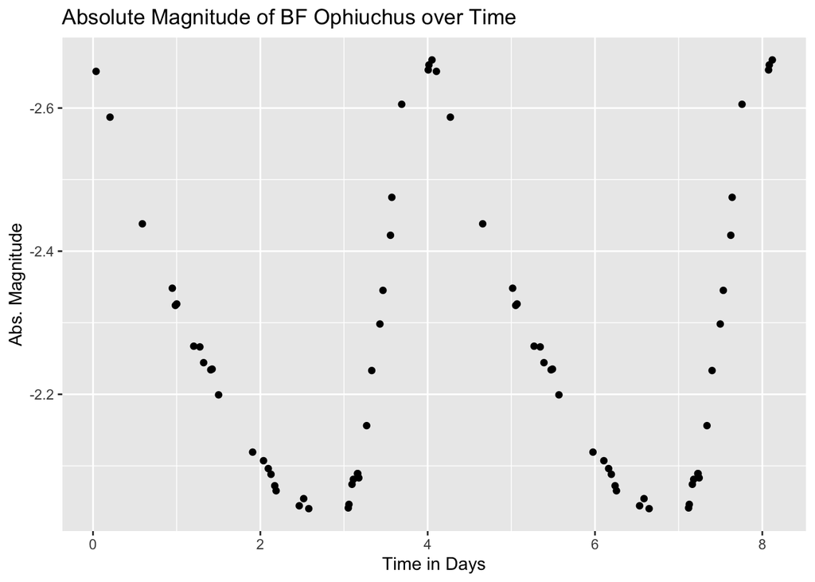

> The smallest Absolute Magnitude (Highest Luminosity) is -2.6672249.  
> The period between light curves is 4.068 days.

## Delta Cepheus

> Parallax = 3.77 millisarcseconds  
> Distance (in parsecs) = 265.252

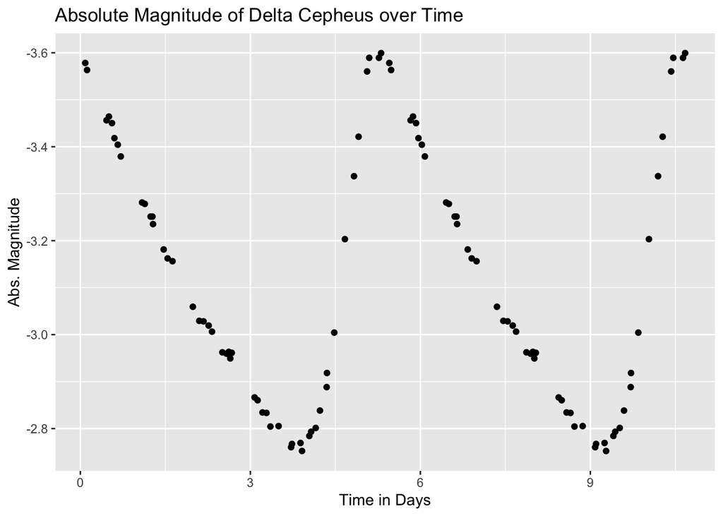

> The smallest Absolute Magnitude (Highest Luminosity) is -3.5992932.  
> The period between light curves is 5.366 days.

## GQ Orion

> Parallax = 0.3873 milliarcseconds  
> Distance (in parsecs) = 2581.978

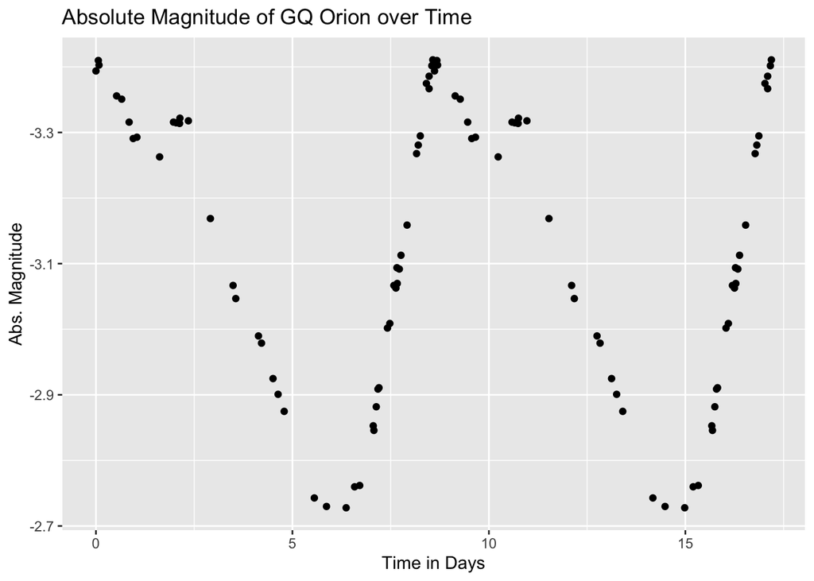

> The smallest Absolute Magnitude (Highest Luminosity) is -3.4107625.  
> The period between light curves is 8.616 days.

## VX Perseus

> Parallax = 0.3298 milliarcseconds  
> Distance (in parsecs) = 3032.141

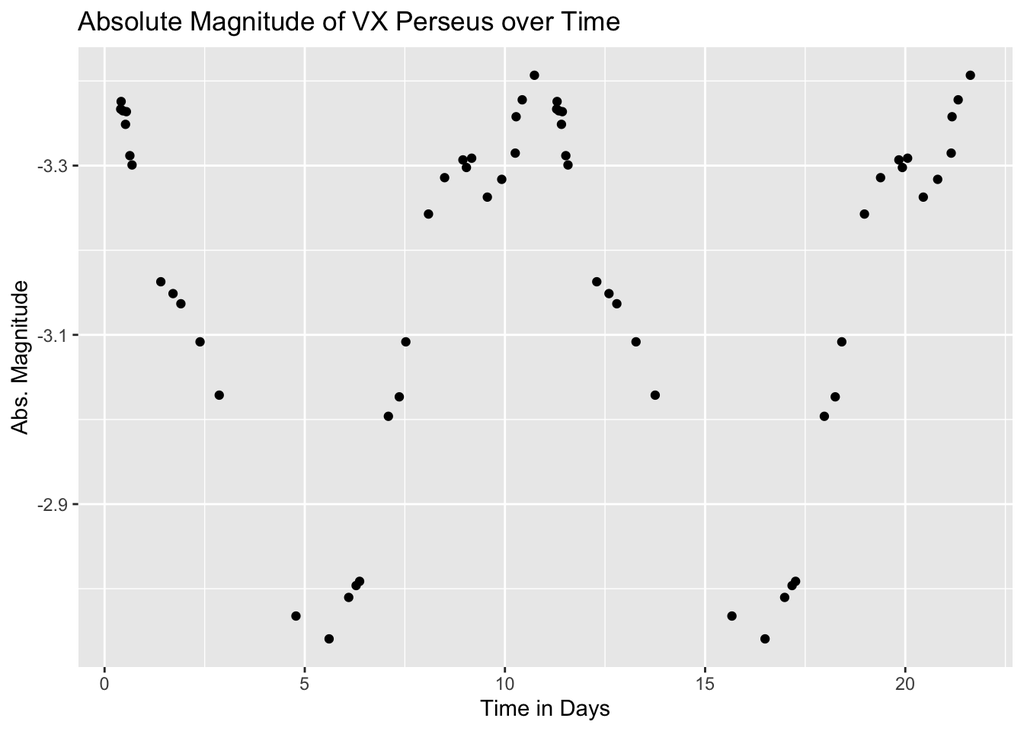

> The smallest Absolute Magnitude (Highest Luminosity) is -3.4067467.  
> The period between light curves is 10.889 days.

# #2: Creating a period-luminosity relation for Milky Way Cepheids

```
## # A tibble: 6 × 7
##   name         peak_abs_mag low_abs_mag parallax parsec period log_period
##   <chr>               <dbl>       <dbl>    <dbl>  <dbl>  <dbl>      <dbl>
## 1 AA Gemini           -4.23       -3.58    0.188  5325.  11.3       1.05
## 2 AO Auriga           -4.10       -3.17    0.127  7886.   6.76      0.830
## 3 BF Ophiuchus        -2.67       -2.04    1.18    850.   4.07      0.609
## 4 Delta Cephus        -3.60       -2.75    3.77    265.   5.37      0.730
## 5 GQ Orion            -3.41       -2.73    0.387  2582.   8.62      0.935
## 6 VX Perseus          -3.41       -2.74    0.330  3032.  10.9       1.04
```

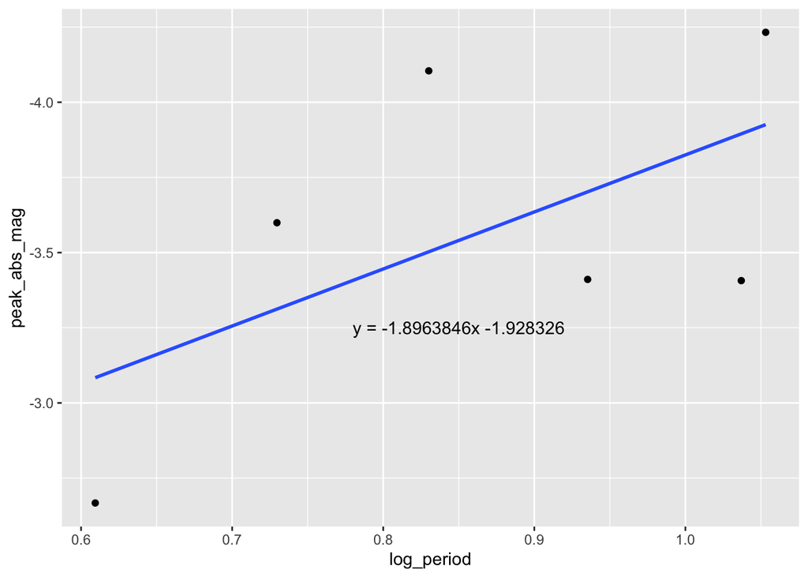

```
## (Intercept)  log_period
##   -1.928326   -1.896385
```

> Peak Absolute Mag = -1.8963846(Log of Period) -1.928326  
> Y = -1.8963846x -1.928326

# #3: Creating a light curve of a Cepheid in NGC 300

## V2

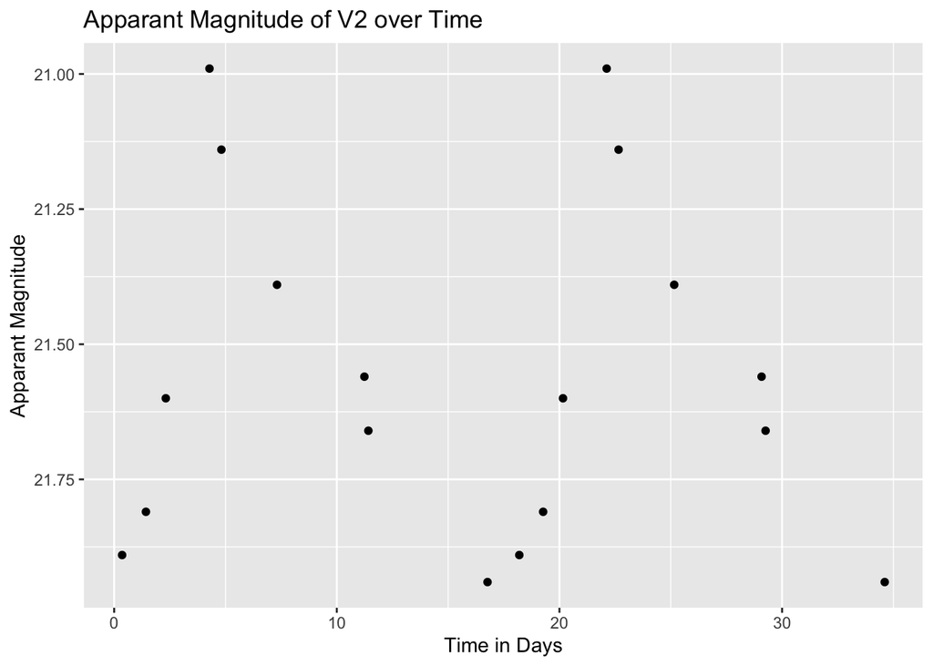

> The max Apparant Magnitude (Highest Luminosity) is 20.99.  
> The period between light curves is 17.84 days.

## V3

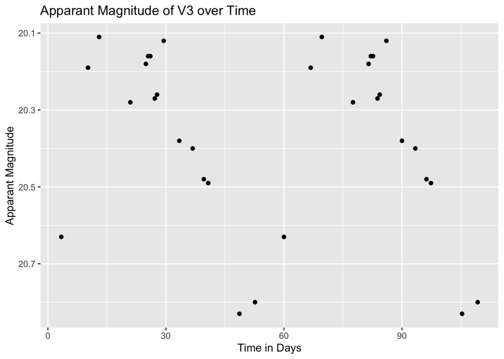

> The max Apparant Magnitude (Highest Luminosity) is 20.11.  
> The period between light curves is 56.61 days.

## V9

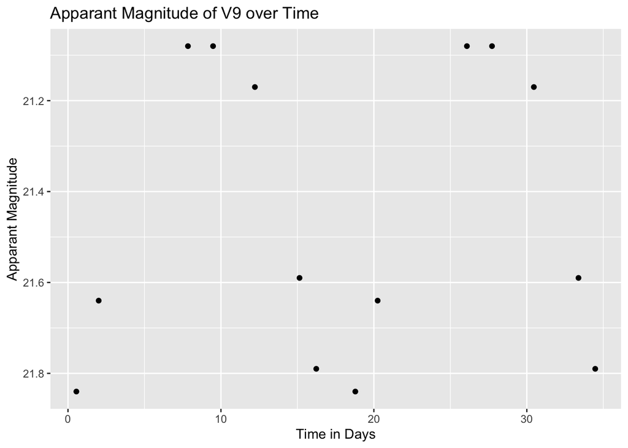

> The max Apparant Magnitude (Highest Luminosity) is 21.08.  
> The period between light curves is 18.24 days.

## V10

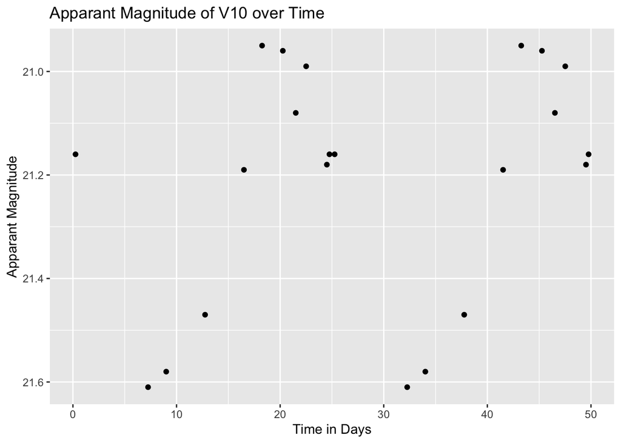

> The max Apparant Magnitude (Highest Luminosity) is 20.95.  
> The period between light curves is 25.01 days.

## V29

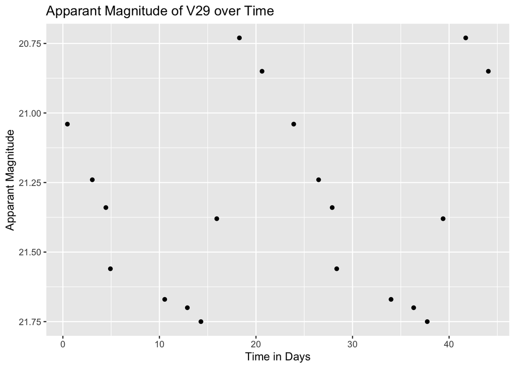

> The max Apparant Magnitude (Highest Luminosity) is 20.73.  
> The period between light curves is 23.44 days.

```
## # A tibble: 5 × 5
##   name  max_magnitude min_magnitude period log_period
##   <chr>         <dbl>         <dbl>  <dbl>      <dbl>
## 1 V2             21.0          21.9   17.8       1.25
## 2 V3             20.1          20.8   56.6       1.75
## 3 V9             21.1          21.8   18.2       1.26
## 4 V10            21.0          21.6   25.0       1.40
## 5 V29            20.7          21.8   23.4       1.37
```

## Estimating Distance:

> We remember our equation derived from an earlier model to calculate the Peak Absolute Magnitude:  
> Peak Absolute Mag = -1.8963846(Log of Period) -1.928326  
> Using this, we can create a function to calulate this for us.

```r
calc_mag = function(log_period) {
  return (slope * log_period + intercept)
}
```

> Putting each cepheid’s log of its period into the above equation, we can derive the Estimated Absolute Magnitude.

```
## # A tibble: 5 × 3
##   name  log_period estimated_abs_magnitude
##   <chr>      <dbl>                   <dbl>
## 1 V2          1.25                   -4.30
## 2 V3          1.75                   -5.25
## 3 V9          1.26                   -4.32
## 4 V10         1.40                   -4.58
## 5 V29         1.37                   -4.53
```

> Finally, we create our last function, which takes in the peak apparent magnitude ‘m’, and our estimated absolute magnitude ‘M’, and it returns us the distance to the cepheid in terms of parsecs.

```r
distance = function(m, M) {
  return (10 ^ ( (m-M+5) / 5)  )
}
```

> Plugging each star into our function, we get our final answer of the estimated distance to each cepheid.

```
## # A tibble: 5 × 4
##   name  max_magnitude estimated_abs_magnitude distance_in_parsecs
##   <chr>         <dbl>                   <dbl>               <dbl>
## 1 V2             21.0                   -4.30            1143643.
## 2 V3             20.1                   -5.25            1181672.
## 3 V9             21.1                   -4.32            1202106.
## 4 V10            21.0                   -4.58            1276255.
## 5 V29            20.7                   -4.53            1125275.
```

# #4: Discussion Questions

> 1. If you were an astronomer in the early 20th century, before there was conclusive evidence of other galaxies, would your distance measurement suggest that NGC 300 is its own galaxy or part of the Milky Way?

##### With evidence that these 5 cephids are clustered together, but extremely far from the Milky Way, I would have to conclude that NGC 300 is too far to be considered a part of the Milky Way Galaxy. I would have to say that NGC 300 is its own galaxy, or something else.

> 2. In 2006, a group of astronomers used a technique based on a different kind of standard candle to estimate the distance to NGC 300, and found it to be ~1.86 million parsecs. How does this compare to your measurement? Why do you think it’s important to have multiple independent measurements of distance (or, really, any quantity) in astronomy?

##### In terms of orders of magnitude, the 2006 measurement is in the same oder as my experiment (1.86 million vs ~1.2 million). Both experiments used the same reasoning (standard candles) but got slightly different results. It’s important to have multiple independent measurements of everything in astronomy because it’s possible that using the same style of experiment can produce different results. With a small sample size, it’s difficult to say who is more accurate.

> 3. How do the periods of the Cepheids in NGC 300 you found compare to the periods of Cepheids in the Milky Way? If they’re different (on average), what does that say about the Cepheids we see in NGC 300?

##### The periods of the Cepheids in NGC 300 are much longer than the periods of the Cepheids in the Milky Way. This could suggest that the NGC 300 Cepheids have a larger mass than the ones in the Milky Way.

## Limits of the experiment

##### Unfortunately, this cannot guarantee my model to be accurate as it only accounts for Cepheids with periods ranging from around 4-11 days. The periods in the NGC 300 Cepheids range from around 18-57 days.